# Risk Factor Analysis

## Outcome Variable

**Outcome Variable:** stunted

## Predictor Variables

**Intervention Variable:** birthlen

**Adjustment Set:**

unadjusted

## Stratifying Variables

The analysis was stratified on these variable(s):

- agecat
- studyid
- country

## Data Summary

| agecat | studyid | country | birthlen | stunted | n_cell | n |
| --- | --- | --- | --- | --- | --- | --- |
| Birth | ki0047075b-MAL-ED | BANGLADESH | >=50 cm | 0 | 29 | 257 |
| Birth | ki0047075b-MAL-ED | BANGLADESH | >=50 cm | 1 | 0 | 257 |
| Birth | ki0047075b-MAL-ED | BANGLADESH | <48 cm | 0 | 97 | 257 |
| Birth | ki0047075b-MAL-ED | BANGLADESH | <48 cm | 1 | 47 | 257 |
| Birth | ki0047075b-MAL-ED | BANGLADESH | [48-50) cm | 0 | 84 | 257 |
| Birth | ki0047075b-MAL-ED | BANGLADESH | [48-50) cm | 1 | 0 | 257 |
| Birth | ki0047075b-MAL-ED | BRAZIL | >=50 cm | 0 | 34 | 191 |
| Birth | ki0047075b-MAL-ED | BRAZIL | >=50 cm | 1 | 0 | 191 |
| Birth | ki0047075b-MAL-ED | BRAZIL | <48 cm | 0 | 59 | 191 |
| Birth | ki0047075b-MAL-ED | BRAZIL | <48 cm | 1 | 21 | 191 |
| Birth | ki0047075b-MAL-ED | BRAZIL | [48-50) cm | 0 | 77 | 191 |
| Birth | ki0047075b-MAL-ED | BRAZIL | [48-50) cm | 1 | 0 | 191 |
| Birth | ki0047075b-MAL-ED | INDIA | >=50 cm | 0 | 25 | 206 |
| Birth | ki0047075b-MAL-ED | INDIA | >=50 cm | 1 | 0 | 206 |
| Birth | ki0047075b-MAL-ED | INDIA | <48 cm | 0 | 74 | 206 |
| Birth | ki0047075b-MAL-ED | INDIA | <48 cm | 1 | 33 | 206 |
| Birth | ki0047075b-MAL-ED | INDIA | [48-50) cm | 0 | 74 | 206 |
| Birth | ki0047075b-MAL-ED | INDIA | [48-50) cm | 1 | 0 | 206 |
| Birth | ki0047075b-MAL-ED | NEPAL | >=50 cm | 0 | 38 | 173 |
| Birth | ki0047075b-MAL-ED | NEPAL | >=50 cm | 1 | 0 | 173 |
| Birth | ki0047075b-MAL-ED | NEPAL | <48 cm | 0 | 51 | 173 |
| Birth | ki0047075b-MAL-ED | NEPAL | <48 cm | 1 | 18 | 173 |
| Birth | ki0047075b-MAL-ED | NEPAL | [48-50) cm | 0 | 66 | 173 |
| Birth | ki0047075b-MAL-ED | NEPAL | [48-50) cm | 1 | 0 | 173 |
| Birth | ki0047075b-MAL-ED | PERU | >=50 cm | 0 | 34 | 287 |
| Birth | ki0047075b-MAL-ED | PERU | >=50 cm | 1 | 0 | 287 |
| Birth | ki0047075b-MAL-ED | PERU | <48 cm | 0 | 108 | 287 |
| Birth | ki0047075b-MAL-ED | PERU | <48 cm | 1 | 34 | 287 |
| Birth | ki0047075b-MAL-ED | PERU | [48-50) cm | 0 | 111 | 287 |
| Birth | ki0047075b-MAL-ED | PERU | [48-50) cm | 1 | 0 | 287 |

[output cut: 432 more lines]

The following strata were considered:

- agecat: 24 months, studyid: ki0047075b-MAL-ED, country: BANGLADESH
- agecat: 24 months, studyid: ki0047075b-MAL-ED, country: BRAZIL
- agecat: 24 months, studyid: ki0047075b-MAL-ED, country: INDIA
- agecat: 24 months, studyid: ki0047075b-MAL-ED, country: NEPAL
- agecat: 24 months, studyid: ki0047075b-MAL-ED, country: PERU
- agecat: 24 months, studyid: ki0047075b-MAL-ED, country: SOUTH AFRICA
- agecat: 24 months, studyid: ki0047075b-MAL-ED, country: TANZANIA, UNITED REPUBLIC OF
- agecat: 24 months, studyid: ki1000108-CMC-V-BCS-2002, country: INDIA
- agecat: 24 months, studyid: ki1000108-IRC, country: INDIA
- agecat: 24 months, studyid: ki1017093-NIH-Birth, country: BANGLADESH
- agecat: 24 months, studyid: ki1017093b-PROVIDE, country: BANGLADESH
- agecat: 24 months, studyid: ki1017093c-NIH-Crypto, country: BANGLADESH
- agecat: 24 months, studyid: ki1101329-Keneba, country: GAMBIA
- agecat: 24 months, studyid: ki1114097-CMIN, country: BANGLADESH
- agecat: 24 months, studyid: ki1114097-CMIN, country: PERU
- agecat: 24 months, studyid: ki1114097-CONTENT, country: PERU
- agecat: 24 months, studyid: ki1119695-PROBIT, country: BELARUS
- agecat: 24 months, studyid: ki1126311-ZVITAMBO, country: ZIMBABWE
- agecat: 24 months, studyid: ki1135781-COHORTS, country: GUATEMALA
- agecat: 24 months, studyid: ki1135781-COHORTS, country: INDIA
- agecat: 24 months, studyid: ki1135781-COHORTS, country: PHILIPPINES
- agecat: 24 months, studyid: kiGH5241-JiVitA-3, country: BANGLADESH
- agecat: 24 months, studyid: kiGH5241-JiVitA-4, country: BANGLADESH
- agecat: 6 months, studyid: ki0047075b-MAL-ED, country: BANGLADESH
- agecat: 6 months, studyid: ki0047075b-MAL-ED, country: BRAZIL
- agecat: 6 months, studyid: ki0047075b-MAL-ED, country: INDIA
- agecat: 6 months, studyid: ki0047075b-MAL-ED, country: NEPAL
- agecat: 6 months, studyid: ki0047075b-MAL-ED, country: PERU
- agecat: 6 months, studyid: ki0047075b-MAL-ED, country: SOUTH AFRICA
- agecat: 6 months, studyid: ki0047075b-MAL-ED, country: TANZANIA, UNITED REPUBLIC OF
- agecat: 6 months, studyid: ki1000108-CMC-V-BCS-2002, country: INDIA
- agecat: 6 months, studyid: ki1000108-IRC, country: INDIA
- agecat: 6 months, studyid: ki1000109-EE, country: PAKISTAN
- agecat: 6 months, studyid: ki1000109-ResPak, country: PAKISTAN
- agecat: 6 months, studyid: ki1000304b-SAS-CompFeed, country: INDIA
- agecat: 6 months, studyid: ki1017093-NIH-Birth, country: BANGLADESH
- agecat: 6 months, studyid: ki1017093b-PROVIDE, country: BANGLADESH
- agecat: 6 months, studyid: ki1017093c-NIH-Crypto, country: BANGLADESH
- agecat: 6 months, studyid: ki1101329-Keneba, country: GAMBIA
- agecat: 6 months, studyid: ki1114097-CMIN, country: BANGLADESH
- agecat: 6 months, studyid: ki1114097-CMIN, country: BRAZIL
- agecat: 6 months, studyid: ki1114097-CMIN, country: GUINEA-BISSAU
- agecat: 6 months, studyid: ki1114097-CMIN, country: PERU
- agecat: 6 months, studyid: ki1114097-CONTENT, country: PERU
- agecat: 6 months, studyid: ki1119695-PROBIT, country: BELARUS
- agecat: 6 months, studyid: ki1126311-ZVITAMBO, country: ZIMBABWE
- agecat: 6 months, studyid: ki1135781-COHORTS, country: GUATEMALA
- agecat: 6 months, studyid: ki1135781-COHORTS, country: INDIA
- agecat: 6 months, studyid: ki1135781-COHORTS, country: PHILIPPINES
- agecat: 6 months, studyid: kiGH5241-JiVitA-3, country: BANGLADESH
- agecat: 6 months, studyid: kiGH5241-JiVitA-4, country: BANGLADESH
- agecat: Birth, studyid: ki0047075b-MAL-ED, country: BANGLADESH
- agecat: Birth, studyid: ki0047075b-MAL-ED, country: BRAZIL
- agecat: Birth, studyid: ki0047075b-MAL-ED, country: INDIA
- agecat: Birth, studyid: ki0047075b-MAL-ED, country: NEPAL
- agecat: Birth, studyid: ki0047075b-MAL-ED, country: PERU
- agecat: Birth, studyid: ki0047075b-MAL-ED, country: SOUTH AFRICA
- agecat: Birth, studyid: ki0047075b-MAL-ED, country: TANZANIA, UNITED REPUBLIC OF
- agecat: Birth, studyid: ki1000108-CMC-V-BCS-2002, country: INDIA
- agecat: Birth, studyid: ki1000108-IRC, country: INDIA
- agecat: Birth, studyid: ki1000109-EE, country: PAKISTAN
- agecat: Birth, studyid: ki1000109-ResPak, country: PAKISTAN
- agecat: Birth, studyid: ki1000304b-SAS-CompFeed, country: INDIA
- agecat: Birth, studyid: ki1017093-NIH-Birth, country: BANGLADESH
- agecat: Birth, studyid: ki1017093c-NIH-Crypto, country: BANGLADESH
- agecat: Birth, studyid: ki1101329-Keneba, country: GAMBIA
- agecat: Birth, studyid: ki1114097-CMIN, country: BANGLADESH
- agecat: Birth, studyid: ki1114097-CMIN, country: BRAZIL
- agecat: Birth, studyid: ki1114097-CMIN, country: PERU
- agecat: Birth, studyid: ki1114097-CONTENT, country: PERU
- agecat: Birth, studyid: ki1119695-PROBIT, country: BELARUS
- agecat: Birth, studyid: ki1126311-ZVITAMBO, country: ZIMBABWE
- agecat: Birth, studyid: ki1135781-COHORTS, country: GUATEMALA
- agecat: Birth, studyid: ki1135781-COHORTS, country: INDIA
- agecat: Birth, studyid: ki1135781-COHORTS, country: PHILIPPINES
- agecat: Birth, studyid: kiGH5241-JiVitA-3, country: BANGLADESH
- agecat: Birth, studyid: kiGH5241-JiVitA-4, country: BANGLADESH

### Dropped Strata

Some strata were dropped due to rare outcomes:

- agecat: Birth, studyid: ki0047075b-MAL-ED, country: BANGLADESH
- agecat: Birth, studyid: ki0047075b-MAL-ED, country: BRAZIL
- agecat: Birth, studyid: ki0047075b-MAL-ED, country: INDIA
- agecat: Birth, studyid: ki0047075b-MAL-ED, country: NEPAL
- agecat: Birth, studyid: ki0047075b-MAL-ED, country: PERU
- agecat: Birth, studyid: ki0047075b-MAL-ED, country: SOUTH AFRICA
- agecat: Birth, studyid: ki0047075b-MAL-ED, country: TANZANIA, UNITED REPUBLIC OF
- agecat: Birth, studyid: ki1000108-CMC-V-BCS-2002, country: INDIA
- agecat: Birth, studyid: ki1000108-IRC, country: INDIA
- agecat: Birth, studyid: ki1000109-EE, country: PAKISTAN
- agecat: Birth, studyid: ki1000109-ResPak, country: PAKISTAN
- agecat: Birth, studyid: ki1000304b-SAS-CompFeed, country: INDIA
- agecat: Birth, studyid: ki1017093-NIH-Birth, country: BANGLADESH
- agecat: Birth, studyid: ki1017093c-NIH-Crypto, country: BANGLADESH
- agecat: Birth, studyid: ki1101329-Keneba, country: GAMBIA
- agecat: Birth, studyid: ki1114097-CMIN, country: BANGLADESH
- agecat: Birth, studyid: ki1114097-CMIN, country: BRAZIL
- agecat: Birth, studyid: ki1114097-CMIN, country: PERU
- agecat: Birth, studyid: ki1114097-CONTENT, country: PERU
- agecat: Birth, studyid: ki1119695-PROBIT, country: BELARUS
- agecat: Birth, studyid: ki1126311-ZVITAMBO, country: ZIMBABWE
- agecat: Birth, studyid: ki1135781-COHORTS, country: GUATEMALA
- agecat: Birth, studyid: ki1135781-COHORTS, country: INDIA
- agecat: Birth, studyid: ki1135781-COHORTS, country: PHILIPPINES
- agecat: Birth, studyid: kiGH5241-JiVitA-3, country: BANGLADESH
- agecat: Birth, studyid: kiGH5241-JiVitA-4, country: BANGLADESH
- agecat: 6 months, studyid: ki0047075b-MAL-ED, country: BANGLADESH
- agecat: 6 months, studyid: ki0047075b-MAL-ED, country: BRAZIL
- agecat: 6 months, studyid: ki0047075b-MAL-ED, country: INDIA
- agecat: 6 months, studyid: ki0047075b-MAL-ED, country: NEPAL
- agecat: 6 months, studyid: ki0047075b-MAL-ED, country: PERU
- agecat: 6 months, studyid: ki0047075b-MAL-ED, country: SOUTH AFRICA
- agecat: 6 months, studyid: ki0047075b-MAL-ED, country: TANZANIA, UNITED REPUBLIC OF
- agecat: 6 months, studyid: ki1000109-EE, country: PAKISTAN
- agecat: 6 months, studyid: ki1000109-ResPak, country: PAKISTAN
- agecat: 6 months, studyid: ki1017093-NIH-Birth, country: BANGLADESH
- agecat: 6 months, studyid: ki1017093b-PROVIDE, country: BANGLADESH
- agecat: 6 months, studyid: ki1017093c-NIH-Crypto, country: BANGLADESH
- agecat: 6 months, studyid: ki1114097-CMIN, country: BANGLADESH
- agecat: 6 months, studyid: ki1114097-CMIN, country: BRAZIL
- agecat: 6 months, studyid: ki1114097-CMIN, country: GUINEA-BISSAU
- agecat: 6 months, studyid: ki1114097-CMIN, country: PERU
- agecat: 6 months, studyid: ki1114097-CONTENT, country: PERU
- agecat: 24 months, studyid: ki0047075b-MAL-ED, country: BANGLADESH
- agecat: 24 months, studyid: ki0047075b-MAL-ED, country: BRAZIL
- agecat: 24 months, studyid: ki0047075b-MAL-ED, country: INDIA
- agecat: 24 months, studyid: ki0047075b-MAL-ED, country: NEPAL
- agecat: 24 months, studyid: ki0047075b-MAL-ED, country: TANZANIA, UNITED REPUBLIC OF
- agecat: 24 months, studyid: ki1017093-NIH-Birth, country: BANGLADESH
- agecat: 24 months, studyid: ki1114097-CMIN, country: BANGLADESH
- agecat: 24 months, studyid: ki1114097-CMIN, country: PERU
- agecat: 24 months, studyid: ki1114097-CONTENT, country: PERU

## Methods Detail

We’re interested in the causal parameters $E[Y_a]$ for all values of $a \in \mathcal{A}$. These parameters represent the mean outcome if, possibly contrary to fact, we intervened to set all units to have $A=a$. Under the randomization and positivity assumptions, these are identified by the statistical parameters $\psi_a=E_W[E_{Y|A,W}(Y|A=a,W)]$. In addition, we’re interested in the mean of $Y$, $E[Y]$ under no intervention (the observed mean). We will estimate these parameters by using SuperLearner to fit the relevant likelihood factors – $E_{Y|A,W}(Y|A=a,W)$ and $p(A=a|W)$, and then updating our likelihood fit using a joint TMLE.

For unadjusted analyses ($W=\{\}$), initial likelihoods were estimated using Lrnr_glm to estimate the simple $E(Y|A)$ and Lrnr_mean to estimate $p(A)$. For adjusted analyses, a small library containing Lrnr_glmnet, Lrnr_xgboost, and Lrnr_mean was used.

Having estimated these parameters, we will then use the delta method to estimate relative risks and attributable risks relative to a prespecified baseline level of $A$.

# Results Detail

## Results Plots

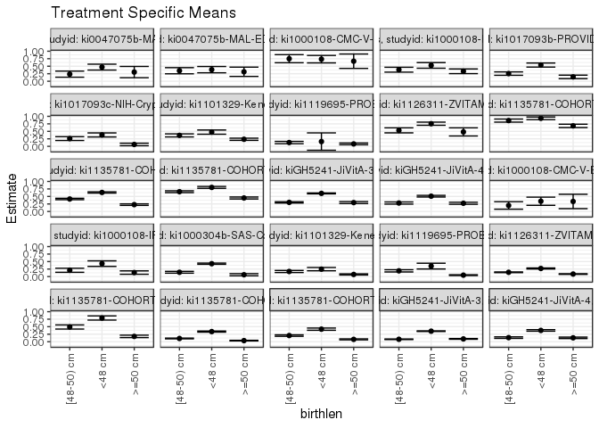

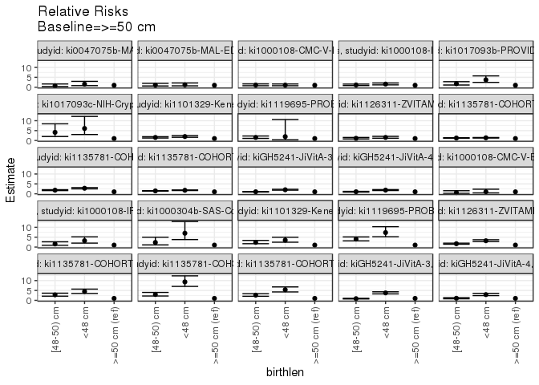

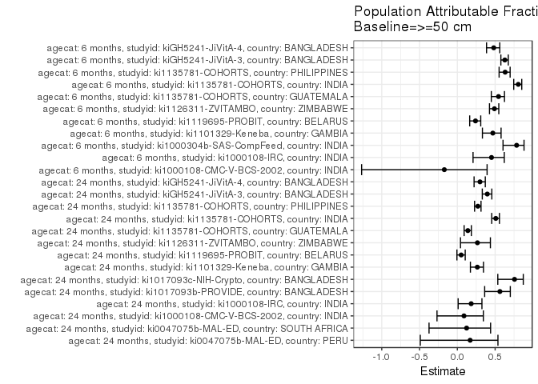

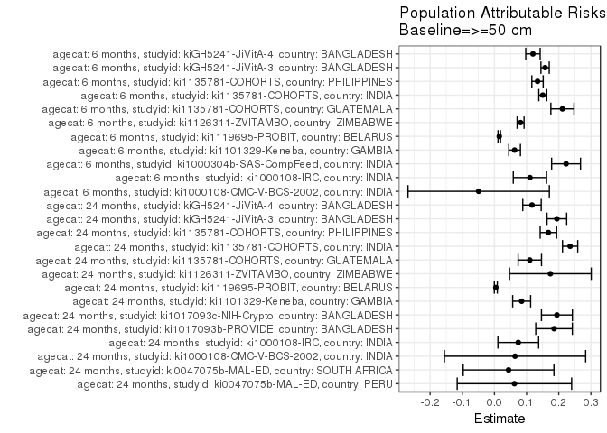

## Results Table

### Parameter: TSM

| agecat | studyid | country | intervention_level | baseline_level | estimate | ci_lower | ci_upper |
| --- | --- | --- | --- | --- | --- | --- | --- |
| 6 months | ki1000108-CMC-V-BCS-2002 | INDIA | >=50 cm | NA | 0.3333333 | 0.0935960 | 0.5730706 |
| 6 months | ki1000108-CMC-V-BCS-2002 | INDIA | <48 cm | NA | 0.3404255 | 0.2042869 | 0.4765642 |
| 6 months | ki1000108-CMC-V-BCS-2002 | INDIA | [48-50) cm | NA | 0.2000000 | 0.0754288 | 0.3245712 |
| 6 months | ki1000108-IRC | INDIA | >=50 cm | NA | 0.1338028 | 0.0777363 | 0.1898694 |
| 6 months | ki1000108-IRC | INDIA | <48 cm | NA | 0.4311927 | 0.3381007 | 0.5242846 |
| 6 months | ki1000108-IRC | INDIA | [48-50) cm | NA | 0.2101449 | 0.1420836 | 0.2782063 |
| 6 months | ki1000304b-SAS-CompFeed | INDIA | >=50 cm | NA | 0.0612245 | 0.0254605 | 0.0969884 |
| 6 months | ki1000304b-SAS-CompFeed | INDIA | <48 cm | NA | 0.4287729 | 0.4084589 | 0.4490869 |
| 6 months | ki1000304b-SAS-CompFeed | INDIA | [48-50) cm | NA | 0.1431981 | 0.1127119 | 0.1736842 |
| 6 months | ki1101329-Keneba | GAMBIA | >=50 cm | NA | 0.0709010 | 0.0515603 | 0.0902417 |
| 6 months | ki1101329-Keneba | GAMBIA | <48 cm | NA | 0.2478632 | 0.1925211 | 0.3032054 |
| 6 months | ki1101329-Keneba | GAMBIA | [48-50) cm | NA | 0.1697248 | 0.1344755 | 0.2049740 |
| 6 months | ki1119695-PROBIT | BELARUS | >=50 cm | NA | 0.0476357 | 0.0340369 | 0.0612345 |
| 6 months | ki1119695-PROBIT | BELARUS | <48 cm | NA | 0.3488372 | 0.2527273 | 0.4449472 |
| 6 months | ki1119695-PROBIT | BELARUS | [48-50) cm | NA | 0.1910286 | 0.1538624 | 0.2281948 |
| 6 months | ki1126311-ZVITAMBO | ZIMBABWE | >=50 cm | NA | 0.0844075 | 0.0732963 | 0.0955186 |
| 6 months | ki1126311-ZVITAMBO | ZIMBABWE | <48 cm | NA | 0.2698413 | 0.2527224 | 0.2869601 |
| 6 months | ki1126311-ZVITAMBO | ZIMBABWE | [48-50) cm | NA | 0.1429459 | 0.1308519 | 0.1550400 |
| 6 months | ki1135781-COHORTS | GUATEMALA | >=50 cm | NA | 0.1766382 | 0.1367129 | 0.2165635 |
| 6 months | ki1135781-COHORTS | GUATEMALA | <48 cm | NA | 0.7894737 | 0.7201375 | 0.8588099 |
| 6 months | ki1135781-COHORTS | GUATEMALA | [48-50) cm | NA | 0.4901961 | 0.4215469 | 0.5588453 |
| 6 months | ki1135781-COHORTS | INDIA | >=50 cm | NA | 0.0360902 | 0.0260655 | 0.0461149 |
| 6 months | ki1135781-COHORTS | INDIA | <48 cm | NA | 0.3367589 | 0.3183419 | 0.3551759 |
| 6 months | ki1135781-COHORTS | INDIA | [48-50) cm | NA | 0.1072527 | 0.0945364 | 0.1199691 |
| 6 months | ki1135781-COHORTS | PHILIPPINES | >=50 cm | NA | 0.0777778 | 0.0610916 | 0.0944639 |
| 6 months | ki1135781-COHORTS | PHILIPPINES | <48 cm | NA | 0.4180207 | 0.3808597 | 0.4551816 |
| 6 months | ki1135781-COHORTS | PHILIPPINES | [48-50) cm | NA | 0.2050290 | 0.1804168 | 0.2296413 |
| 6 months | kiGH5241-JiVitA-3 | BANGLADESH | >=50 cm | NA | 0.0931575 | 0.0803132 | 0.1060017 |
| 6 months | kiGH5241-JiVitA-3 | BANGLADESH | <48 cm | NA | 0.3504323 | 0.3399072 | 0.3609574 |
| 6 months | kiGH5241-JiVitA-3 | BANGLADESH | [48-50) cm | NA | 0.0804962 | 0.0715225 | 0.0894698 |
| 6 months | kiGH5241-JiVitA-4 | BANGLADESH | >=50 cm | NA | 0.1289737 | 0.1050809 | 0.1528664 |
| 6 months | kiGH5241-JiVitA-4 | BANGLADESH | <48 cm | NA | 0.3759750 | 0.3499611 | 0.4019890 |
| 6 months | kiGH5241-JiVitA-4 | BANGLADESH | [48-50) cm | NA | 0.1355422 | 0.1099866 | 0.1610977 |
| 24 months | ki0047075b-MAL-ED | PERU | >=50 cm | NA | 0.3043478 | 0.1158071 | 0.4928886 |
| 24 months | ki0047075b-MAL-ED | PERU | <48 cm | NA | 0.4700000 | 0.3719213 | 0.5680787 |
| 24 months | ki0047075b-MAL-ED | PERU | [48-50) cm | NA | 0.2352941 | 0.1342092 | 0.3363790 |
| 24 months | ki0047075b-MAL-ED | SOUTH AFRICA | >=50 cm | NA | 0.3142857 | 0.1601047 | 0.4684668 |
| 24 months | ki0047075b-MAL-ED | SOUTH AFRICA | <48 cm | NA | 0.3855422 | 0.2805700 | 0.4905143 |
| 24 months | ki0047075b-MAL-ED | SOUTH AFRICA | [48-50) cm | NA | 0.3493976 | 0.2465700 | 0.4522252 |
| 24 months | ki1000108-CMC-V-BCS-2002 | INDIA | >=50 cm | NA | 0.6666667 | 0.4269522 | 0.9063811 |
| 24 months | ki1000108-CMC-V-BCS-2002 | INDIA | <48 cm | NA | 0.7346939 | 0.6104786 | 0.8589091 |
| 24 months | ki1000108-CMC-V-BCS-2002 | INDIA | [48-50) cm | NA | 0.7500000 | 0.6151606 | 0.8848394 |
| 24 months | ki1000108-IRC | INDIA | >=50 cm | NA | 0.3309859 | 0.2534891 | 0.4084827 |
| 24 months | ki1000108-IRC | INDIA | <48 cm | NA | 0.5272727 | 0.4338544 | 0.6206911 |
| 24 months | ki1000108-IRC | INDIA | [48-50) cm | NA | 0.3840580 | 0.3028059 | 0.4653100 |
| 24 months | ki1017093b-PROVIDE | BANGLADESH | >=50 cm | NA | 0.1438849 | 0.0854878 | 0.2022820 |
| 24 months | ki1017093b-PROVIDE | BANGLADESH | <48 cm | NA | 0.5388350 | 0.4707036 | 0.6069663 |
| 24 months | ki1017093b-PROVIDE | BANGLADESH | [48-50) cm | NA | 0.2543103 | 0.1982260 | 0.3103947 |
| 24 months | ki1017093c-NIH-Crypto | BANGLADESH | >=50 cm | NA | 0.0625000 | 0.0205249 | 0.1044751 |
| 24 months | ki1017093c-NIH-Crypto | BANGLADESH | <48 cm | NA | 0.3800000 | 0.3126646 | 0.4473354 |
| 24 months | ki1017093c-NIH-Crypto | BANGLADESH | [48-50) cm | NA | 0.2580645 | 0.1951194 | 0.3210096 |
| 24 months | ki1101329-Keneba | GAMBIA | >=50 cm | NA | 0.2355140 | 0.1995417 | 0.2714863 |
| 24 months | ki1101329-Keneba | GAMBIA | <48 cm | NA | 0.4744898 | 0.4045494 | 0.5444302 |
| 24 months | ki1101329-Keneba | GAMBIA | [48-50) cm | NA | 0.3652695 | 0.3136064 | 0.4169325 |
| 24 months | ki1119695-PROBIT | BELARUS | >=50 cm | NA | 0.0809123 | 0.0513729 | 0.1104517 |
| 24 months | ki1119695-PROBIT | BELARUS | <48 cm | NA | 0.1590909 | -0.1304727 | 0.4486545 |
| 24 months | ki1119695-PROBIT | BELARUS | [48-50) cm | NA | 0.1266234 | 0.0879311 | 0.1653157 |
| 24 months | ki1126311-ZVITAMBO | ZIMBABWE | >=50 cm | NA | 0.4807692 | 0.3448193 | 0.6167192 |
| 24 months | ki1126311-ZVITAMBO | ZIMBABWE | <48 cm | NA | 0.7538462 | 0.7014270 | 0.8062653 |
| 24 months | ki1126311-ZVITAMBO | ZIMBABWE | [48-50) cm | NA | 0.5328467 | 0.4492089 | 0.6164846 |
| 24 months | ki1135781-COHORTS | GUATEMALA | >=50 cm | NA | 0.6818182 | 0.6255834 | 0.7380529 |
| 24 months | ki1135781-COHORTS | GUATEMALA | <48 cm | NA | 0.9338843 | 0.8895703 | 0.9781983 |
| 24 months | ki1135781-COHORTS | GUATEMALA | [48-50) cm | NA | 0.8587571 | 0.8074040 | 0.9101102 |
| 24 months | ki1135781-COHORTS | INDIA | >=50 cm | NA | 0.2273161 | 0.2019277 | 0.2527046 |
| 24 months | ki1135781-COHORTS | INDIA | <48 cm | NA | 0.6334538 | 0.6119928 | 0.6549148 |
| 24 months | ki1135781-COHORTS | INDIA | [48-50) cm | NA | 0.4153067 | 0.3923928 | 0.4382206 |
| 24 months | ki1135781-COHORTS | PHILIPPINES | >=50 cm | NA | 0.4492754 | 0.4167169 | 0.4818339 |
| 24 months | ki1135781-COHORTS | PHILIPPINES | <48 cm | NA | 0.8013245 | 0.7694976 | 0.8331514 |
| 24 months | ki1135781-COHORTS | PHILIPPINES | [48-50) cm | NA | 0.6588735 | 0.6285764 | 0.6891706 |
| 24 months | kiGH5241-JiVitA-3 | BANGLADESH | >=50 cm | NA | 0.2954740 | 0.2625765 | 0.3283714 |
| 24 months | kiGH5241-JiVitA-3 | BANGLADESH | <48 cm | NA | 0.6024939 | 0.5870660 | 0.6179218 |
| 24 months | kiGH5241-JiVitA-3 | BANGLADESH | [48-50) cm | NA | 0.3025253 | 0.2805333 | 0.3245172 |
| 24 months | kiGH5241-JiVitA-4 | BANGLADESH | >=50 cm | NA | 0.2729805 | 0.2397244 | 0.3062366 |
| 24 months | kiGH5241-JiVitA-4 | BANGLADESH | <48 cm | NA | 0.5087449 | 0.4816806 | 0.5358091 |
| 24 months | kiGH5241-JiVitA-4 | BANGLADESH | [48-50) cm | NA | 0.2805383 | 0.2444702 | 0.3166064 |

### Parameter: E(Y)

| agecat | studyid | country | intervention_level | baseline_level | estimate | ci_lower | ci_upper |
| --- | --- | --- | --- | --- | --- | --- | --- |
| 6 months | ki1000108-CMC-V-BCS-2002 | INDIA | NA | NA | 0.2843137 | 0.1963411 | 0.3722864 |
| 6 months | ki1000108-IRC | INDIA | NA | NA | 0.2442159 | 0.2014677 | 0.2869642 |
| 6 months | ki1000304b-SAS-CompFeed | INDIA | NA | NA | 0.2839879 | 0.2652870 | 0.3026888 |
| 6 months | ki1101329-Keneba | GAMBIA | NA | NA | 0.1336303 | 0.1154530 | 0.1518076 |
| 6 months | ki1119695-PROBIT | BELARUS | NA | NA | 0.0626864 | 0.0488489 | 0.0765239 |
| 6 months | ki1126311-ZVITAMBO | ZIMBABWE | NA | NA | 0.1657324 | 0.1576867 | 0.1737781 |
| 6 months | ki1135781-COHORTS | GUATEMALA | NA | NA | 0.3880814 | 0.3516414 | 0.4245214 |
| 6 months | ki1135781-COHORTS | INDIA | NA | NA | 0.1864711 | 0.1767241 | 0.1962180 |
| 6 months | ki1135781-COHORTS | PHILIPPINES | NA | NA | 0.2117734 | 0.1963625 | 0.2271843 |
| 6 months | kiGH5241-JiVitA-3 | BANGLADESH | NA | NA | 0.2506663 | 0.2425523 | 0.2587804 |
| 6 months | kiGH5241-JiVitA-4 | BANGLADESH | NA | NA | 0.2487562 | 0.2326103 | 0.2649022 |
| 24 months | ki0047075b-MAL-ED | PERU | NA | NA | 0.3664921 | 0.2979781 | 0.4350062 |
| 24 months | ki0047075b-MAL-ED | SOUTH AFRICA | NA | NA | 0.3582090 | 0.2917585 | 0.4246594 |
| 24 months | ki1000108-CMC-V-BCS-2002 | INDIA | NA | NA | 0.7307692 | 0.6451085 | 0.8164300 |
| 24 months | ki1000108-IRC | INDIA | NA | NA | 0.4051282 | 0.3563438 | 0.4539126 |
| 24 months | ki1017093b-PROVIDE | BANGLADESH | NA | NA | 0.3292894 | 0.2909105 | 0.3676684 |
| 24 months | ki1017093c-NIH-Crypto | BANGLADESH | NA | NA | 0.2568093 | 0.2190047 | 0.2946140 |
| 24 months | ki1101329-Keneba | GAMBIA | NA | NA | 0.3201878 | 0.2921545 | 0.3482211 |
| 24 months | ki1119695-PROBIT | BELARUS | NA | NA | 0.0852540 | 0.0554439 | 0.1150642 |
| 24 months | ki1126311-ZVITAMBO | ZIMBABWE | NA | NA | 0.6547884 | 0.6107631 | 0.6988137 |
| 24 months | ki1135781-COHORTS | GUATEMALA | NA | NA | 0.7918149 | 0.7582177 | 0.8254122 |
| 24 months | ki1135781-COHORTS | INDIA | NA | NA | 0.4627179 | 0.4485533 | 0.4768825 |
| 24 months | ki1135781-COHORTS | PHILIPPINES | NA | NA | 0.6171171 | 0.5978338 | 0.6364004 |
| 24 months | kiGH5241-JiVitA-3 | BANGLADESH | NA | NA | 0.4895784 | 0.4764028 | 0.5027539 |
| 24 months | kiGH5241-JiVitA-4 | BANGLADESH | NA | NA | 0.3897667 | 0.3711087 | 0.4084248 |

### Parameter: RR

| agecat | studyid | country | intervention_level | baseline_level | estimate | ci_lower | ci_upper |
| --- | --- | --- | --- | --- | --- | --- | --- |
| 6 months | ki1000108-CMC-V-BCS-2002 | INDIA | >=50 cm | >=50 cm | 1.0000000 | 1.0000000 | 1.000000 |
| 6 months | ki1000108-CMC-V-BCS-2002 | INDIA | <48 cm | >=50 cm | 1.0212766 | 0.4484926 | 2.325581 |
| 6 months | ki1000108-CMC-V-BCS-2002 | INDIA | [48-50) cm | >=50 cm | 0.6000000 | 0.2317135 | 1.553643 |
| 6 months | ki1000108-IRC | INDIA | >=50 cm | >=50 cm | 1.0000000 | 1.0000000 | 1.000000 |
| 6 months | ki1000108-IRC | INDIA | <48 cm | >=50 cm | 3.2225978 | 2.0113704 | 5.163214 |
| 6 months | ki1000108-IRC | INDIA | [48-50) cm | >=50 cm | 1.5705568 | 0.9248058 | 2.667207 |
| 6 months | ki1000304b-SAS-CompFeed | INDIA | >=50 cm | >=50 cm | 1.0000000 | 1.0000000 | 1.000000 |
| 6 months | ki1000304b-SAS-CompFeed | INDIA | <48 cm | >=50 cm | 7.0032910 | 3.7970374 | 12.916935 |
| 6 months | ki1000304b-SAS-CompFeed | INDIA | [48-50) cm | >=50 cm | 2.3389021 | 1.1000366 | 4.972983 |
| 6 months | ki1101329-Keneba | GAMBIA | >=50 cm | >=50 cm | 1.0000000 | 1.0000000 | 1.000000 |
| 6 months | ki1101329-Keneba | GAMBIA | <48 cm | >=50 cm | 3.4959046 | 2.4573443 | 4.973397 |
| 6 months | ki1101329-Keneba | GAMBIA | [48-50) cm | >=50 cm | 2.3938265 | 1.6990100 | 3.372791 |
| 6 months | ki1119695-PROBIT | BELARUS | >=50 cm | >=50 cm | 1.0000000 | 1.0000000 | 1.000000 |
| 6 months | ki1119695-PROBIT | BELARUS | <48 cm | >=50 cm | 7.3230201 | 5.2108424 | 10.291354 |
| 6 months | ki1119695-PROBIT | BELARUS | [48-50) cm | >=50 cm | 4.0101983 | 3.1403696 | 5.120955 |
| 6 months | ki1126311-ZVITAMBO | ZIMBABWE | >=50 cm | >=50 cm | 1.0000000 | 1.0000000 | 1.000000 |
| 6 months | ki1126311-ZVITAMBO | ZIMBABWE | <48 cm | >=50 cm | 3.1968880 | 2.7622657 | 3.699895 |
| 6 months | ki1126311-ZVITAMBO | ZIMBABWE | [48-50) cm | >=50 cm | 1.6935220 | 1.4482111 | 1.980386 |
| 6 months | ki1135781-COHORTS | GUATEMALA | >=50 cm | >=50 cm | 1.0000000 | 1.0000000 | 1.000000 |
| 6 months | ki1135781-COHORTS | GUATEMALA | <48 cm | >=50 cm | 4.4694397 | 3.5070357 | 5.695948 |
| 6 months | ki1135781-COHORTS | GUATEMALA | [48-50) cm | >=50 cm | 2.7751423 | 2.1271962 | 3.620453 |
| 6 months | ki1135781-COHORTS | INDIA | >=50 cm | >=50 cm | 1.0000000 | 1.0000000 | 1.000000 |
| 6 months | ki1135781-COHORTS | INDIA | <48 cm | >=50 cm | 9.3310277 | 7.0304119 | 12.384492 |
| 6 months | ki1135781-COHORTS | INDIA | [48-50) cm | >=50 cm | 2.9717949 | 2.1971317 | 4.019588 |
| 6 months | ki1135781-COHORTS | PHILIPPINES | >=50 cm | >=50 cm | 1.0000000 | 1.0000000 | 1.000000 |
| 6 months | ki1135781-COHORTS | PHILIPPINES | <48 cm | >=50 cm | 5.3745516 | 4.2607697 | 6.779481 |
| 6 months | ki1135781-COHORTS | PHILIPPINES | [48-50) cm | >=50 cm | 2.6360873 | 2.0615500 | 3.370744 |
| 6 months | kiGH5241-JiVitA-3 | BANGLADESH | >=50 cm | >=50 cm | 1.0000000 | 1.0000000 | 1.000000 |
| 6 months | kiGH5241-JiVitA-3 | BANGLADESH | <48 cm | >=50 cm | 3.7617205 | 3.2731627 | 4.323201 |
| 6 months | kiGH5241-JiVitA-3 | BANGLADESH | [48-50) cm | >=50 cm | 0.8640872 | 0.7247643 | 1.030193 |
| 6 months | kiGH5241-JiVitA-4 | BANGLADESH | >=50 cm | >=50 cm | 1.0000000 | 1.0000000 | 1.000000 |
| 6 months | kiGH5241-JiVitA-4 | BANGLADESH | <48 cm | >=50 cm | 2.9151304 | 2.3897807 | 3.555969 |
| 6 months | kiGH5241-JiVitA-4 | BANGLADESH | [48-50) cm | >=50 cm | 1.0509291 | 0.8110880 | 1.361692 |
| 24 months | ki0047075b-MAL-ED | PERU | >=50 cm | >=50 cm | 1.0000000 | 1.0000000 | 1.000000 |
| 24 months | ki0047075b-MAL-ED | PERU | <48 cm | >=50 cm | 1.5442857 | 0.8032154 | 2.969090 |
| 24 months | ki0047075b-MAL-ED | PERU | [48-50) cm | >=50 cm | 0.7731092 | 0.3637769 | 1.643034 |
| 24 months | ki0047075b-MAL-ED | SOUTH AFRICA | >=50 cm | >=50 cm | 1.0000000 | 1.0000000 | 1.000000 |
| 24 months | ki0047075b-MAL-ED | SOUTH AFRICA | <48 cm | >=50 cm | 1.2267251 | 0.6999689 | 2.149888 |
| 24 months | ki0047075b-MAL-ED | SOUTH AFRICA | [48-50) cm | >=50 cm | 1.1117196 | 0.6273984 | 1.969913 |
| 24 months | ki1000108-CMC-V-BCS-2002 | INDIA | >=50 cm | >=50 cm | 1.0000000 | 1.0000000 | 1.000000 |
| 24 months | ki1000108-CMC-V-BCS-2002 | INDIA | <48 cm | >=50 cm | 1.1020408 | 0.7406898 | 1.639679 |
| 24 months | ki1000108-CMC-V-BCS-2002 | INDIA | [48-50) cm | >=50 cm | 1.1250000 | 0.7525933 | 1.681685 |
| 24 months | ki1000108-IRC | INDIA | >=50 cm | >=50 cm | 1.0000000 | 1.0000000 | 1.000000 |
| 24 months | ki1000108-IRC | INDIA | <48 cm | >=50 cm | 1.5930368 | 1.1877067 | 2.136694 |
| 24 months | ki1000108-IRC | INDIA | [48-50) cm | >=50 cm | 1.1603454 | 0.8463310 | 1.590869 |
| 24 months | ki1017093b-PROVIDE | BANGLADESH | >=50 cm | >=50 cm | 1.0000000 | 1.0000000 | 1.000000 |
| 24 months | ki1017093b-PROVIDE | BANGLADESH | <48 cm | >=50 cm | 3.7449029 | 2.4480607 | 5.728738 |
| 24 months | ki1017093b-PROVIDE | BANGLADESH | [48-50) cm | >=50 cm | 1.7674569 | 1.1136413 | 2.805126 |
| 24 months | ki1017093c-NIH-Crypto | BANGLADESH | >=50 cm | >=50 cm | 1.0000000 | 1.0000000 | 1.000000 |
| 24 months | ki1017093c-NIH-Crypto | BANGLADESH | <48 cm | >=50 cm | 6.0800000 | 3.0356333 | 12.177492 |
| 24 months | ki1017093c-NIH-Crypto | BANGLADESH | [48-50) cm | >=50 cm | 4.1290323 | 2.0208559 | 8.436479 |
| 24 months | ki1101329-Keneba | GAMBIA | >=50 cm | >=50 cm | 1.0000000 | 1.0000000 | 1.000000 |
| 24 months | ki1101329-Keneba | GAMBIA | <48 cm | >=50 cm | 2.0146987 | 1.6293880 | 2.491126 |
| 24 months | ki1101329-Keneba | GAMBIA | [48-50) cm | >=50 cm | 1.5509457 | 1.2594767 | 1.909867 |
| 24 months | ki1119695-PROBIT | BELARUS | >=50 cm | >=50 cm | 1.0000000 | 1.0000000 | 1.000000 |
| 24 months | ki1119695-PROBIT | BELARUS | <48 cm | >=50 cm | 1.9662142 | 0.3648546 | 10.595997 |
| 24 months | ki1119695-PROBIT | BELARUS | [48-50) cm | >=50 cm | 1.5649460 | 1.0753775 | 2.277392 |
| 24 months | ki1126311-ZVITAMBO | ZIMBABWE | >=50 cm | >=50 cm | 1.0000000 | 1.0000000 | 1.000000 |
| 24 months | ki1126311-ZVITAMBO | ZIMBABWE | <48 cm | >=50 cm | 1.5680000 | 1.1718702 | 2.098034 |
| 24 months | ki1126311-ZVITAMBO | ZIMBABWE | [48-50) cm | >=50 cm | 1.1083212 | 0.8020592 | 1.531527 |
| 24 months | ki1135781-COHORTS | GUATEMALA | >=50 cm | >=50 cm | 1.0000000 | 1.0000000 | 1.000000 |
| 24 months | ki1135781-COHORTS | GUATEMALA | <48 cm | >=50 cm | 1.3696970 | 1.2453742 | 1.506431 |
| 24 months | ki1135781-COHORTS | GUATEMALA | [48-50) cm | >=50 cm | 1.2595104 | 1.1375172 | 1.394587 |
| 24 months | ki1135781-COHORTS | INDIA | >=50 cm | >=50 cm | 1.0000000 | 1.0000000 | 1.000000 |
| 24 months | ki1135781-COHORTS | INDIA | <48 cm | >=50 cm | 2.7866644 | 2.4796861 | 3.131646 |
| 24 months | ki1135781-COHORTS | INDIA | [48-50) cm | >=50 cm | 1.8270005 | 1.6130118 | 2.069378 |
| 24 months | ki1135781-COHORTS | PHILIPPINES | >=50 cm | >=50 cm | 1.0000000 | 1.0000000 | 1.000000 |
| 24 months | ki1135781-COHORTS | PHILIPPINES | <48 cm | >=50 cm | 1.7835932 | 1.6421243 | 1.937250 |
| 24 months | ki1135781-COHORTS | PHILIPPINES | [48-50) cm | >=50 cm | 1.4665250 | 1.3459083 | 1.597951 |
| 24 months | kiGH5241-JiVitA-3 | BANGLADESH | >=50 cm | >=50 cm | 1.0000000 | 1.0000000 | 1.000000 |
| 24 months | kiGH5241-JiVitA-3 | BANGLADESH | <48 cm | >=50 cm | 2.0390760 | 1.8210199 | 2.283243 |
| 24 months | kiGH5241-JiVitA-3 | BANGLADESH | [48-50) cm | >=50 cm | 1.0238644 | 0.8972996 | 1.168281 |
| 24 months | kiGH5241-JiVitA-4 | BANGLADESH | >=50 cm | >=50 cm | 1.0000000 | 1.0000000 | 1.000000 |
| 24 months | kiGH5241-JiVitA-4 | BANGLADESH | <48 cm | >=50 cm | 1.8636674 | 1.6336639 | 2.126053 |
| 24 months | kiGH5241-JiVitA-4 | BANGLADESH | [48-50) cm | >=50 cm | 1.0276862 | 0.8621095 | 1.225064 |

### Parameter: PAR

| agecat | studyid | country | intervention_level | baseline_level | estimate | ci_lower | ci_upper |
| --- | --- | --- | --- | --- | --- | --- | --- |
| 6 months | ki1000108-CMC-V-BCS-2002 | INDIA | >=50 cm | NA | -0.0490196 | -0.2688128 | 0.1707736 |
| 6 months | ki1000108-IRC | INDIA | >=50 cm | NA | 0.1104131 | 0.0586840 | 0.1621422 |
| 6 months | ki1000304b-SAS-CompFeed | INDIA | >=50 cm | NA | 0.2227634 | 0.1778331 | 0.2676937 |
| 6 months | ki1101329-Keneba | GAMBIA | >=50 cm | NA | 0.0627293 | 0.0446055 | 0.0808530 |
| 6 months | ki1119695-PROBIT | BELARUS | >=50 cm | NA | 0.0150507 | 0.0111680 | 0.0189333 |
| 6 months | ki1126311-ZVITAMBO | ZIMBABWE | >=50 cm | NA | 0.0813249 | 0.0705627 | 0.0920871 |
| 6 months | ki1135781-COHORTS | GUATEMALA | >=50 cm | NA | 0.2114432 | 0.1754511 | 0.2474354 |
| 6 months | ki1135781-COHORTS | INDIA | >=50 cm | NA | 0.1503808 | 0.1380551 | 0.1627066 |
| 6 months | ki1135781-COHORTS | PHILIPPINES | >=50 cm | NA | 0.1339956 | 0.1163373 | 0.1516540 |
| 6 months | kiGH5241-JiVitA-3 | BANGLADESH | >=50 cm | NA | 0.1575089 | 0.1445835 | 0.1704343 |
| 6 months | kiGH5241-JiVitA-4 | BANGLADESH | >=50 cm | NA | 0.1197826 | 0.0973379 | 0.1422272 |
| 24 months | ki0047075b-MAL-ED | PERU | >=50 cm | NA | 0.0621443 | -0.1158461 | 0.2401347 |
| 24 months | ki0047075b-MAL-ED | SOUTH AFRICA | >=50 cm | NA | 0.0439232 | -0.0971751 | 0.1850215 |
| 24 months | ki1000108-CMC-V-BCS-2002 | INDIA | >=50 cm | NA | 0.0641026 | -0.1554992 | 0.2837043 |
| 24 months | ki1000108-IRC | INDIA | >=50 cm | NA | 0.0741423 | 0.0107999 | 0.1374846 |
| 24 months | ki1017093b-PROVIDE | BANGLADESH | >=50 cm | NA | 0.1854045 | 0.1284826 | 0.2423265 |
| 24 months | ki1017093c-NIH-Crypto | BANGLADESH | >=50 cm | NA | 0.1943093 | 0.1462097 | 0.2424089 |
| 24 months | ki1101329-Keneba | GAMBIA | >=50 cm | NA | 0.0846738 | 0.0567490 | 0.1125985 |
| 24 months | ki1119695-PROBIT | BELARUS | >=50 cm | NA | 0.0043417 | -0.0002862 | 0.0089697 |
| 24 months | ki1126311-ZVITAMBO | ZIMBABWE | >=50 cm | NA | 0.1740192 | 0.0469774 | 0.3010610 |
| 24 months | ki1135781-COHORTS | GUATEMALA | >=50 cm | NA | 0.1099968 | 0.0736637 | 0.1463298 |
| 24 months | ki1135781-COHORTS | INDIA | >=50 cm | NA | 0.2354018 | 0.2117013 | 0.2591022 |
| 24 months | ki1135781-COHORTS | PHILIPPINES | >=50 cm | NA | 0.1678418 | 0.1422852 | 0.1933983 |
| 24 months | kiGH5241-JiVitA-3 | BANGLADESH | >=50 cm | NA | 0.1941044 | 0.1635302 | 0.2246787 |
| 24 months | kiGH5241-JiVitA-4 | BANGLADESH | >=50 cm | NA | 0.1167862 | 0.0881303 | 0.1454422 |

### Parameter: PAF

| agecat | studyid | country | intervention_level | baseline_level | estimate | ci_lower | ci_upper |
| --- | --- | --- | --- | --- | --- | --- | --- |
| 6 months | ki1000108-CMC-V-BCS-2002 | INDIA | >=50 cm | NA | -0.1724138 | -1.2667265 | 0.3935951 |
| 6 months | ki1000108-IRC | INDIA | >=50 cm | NA | 0.4521127 | 0.2077826 | 0.6210882 |
| 6 months | ki1000304b-SAS-CompFeed | INDIA | >=50 cm | NA | 0.7844116 | 0.6045629 | 0.8824634 |
| 6 months | ki1101329-Keneba | GAMBIA | >=50 cm | NA | 0.4694239 | 0.3317404 | 0.5787401 |
| 6 months | ki1119695-PROBIT | BELARUS | >=50 cm | NA | 0.2400948 | 0.1635108 | 0.3096673 |
| 6 months | ki1126311-ZVITAMBO | ZIMBABWE | >=50 cm | NA | 0.4907001 | 0.4254984 | 0.5485019 |
| 6 months | ki1135781-COHORTS | GUATEMALA | >=50 cm | NA | 0.5448425 | 0.4494865 | 0.6236815 |
| 6 months | ki1135781-COHORTS | INDIA | >=50 cm | NA | 0.8064567 | 0.7462249 | 0.8523929 |
| 6 months | ki1135781-COHORTS | PHILIPPINES | >=50 cm | NA | 0.6327312 | 0.5526235 | 0.6984947 |
| 6 months | kiGH5241-JiVitA-3 | BANGLADESH | >=50 cm | NA | 0.6283607 | 0.5760739 | 0.6741985 |
| 6 months | kiGH5241-JiVitA-4 | BANGLADESH | >=50 cm | NA | 0.4815259 | 0.3865127 | 0.5618240 |
| 24 months | ki0047075b-MAL-ED | PERU | >=50 cm | NA | 0.1695652 | -0.4902903 | 0.5372567 |
| 24 months | ki0047075b-MAL-ED | SOUTH AFRICA | >=50 cm | NA | 0.1226190 | -0.3745408 | 0.4399604 |
| 24 months | ki1000108-CMC-V-BCS-2002 | INDIA | >=50 cm | NA | 0.0877193 | -0.2691613 | 0.3442472 |
| 24 months | ki1000108-IRC | INDIA | >=50 cm | NA | 0.1830094 | 0.0104833 | 0.3254550 |
| 24 months | ki1017093b-PROVIDE | BANGLADESH | >=50 cm | NA | 0.5630443 | 0.3616962 | 0.7008787 |
| 24 months | ki1017093c-NIH-Crypto | BANGLADESH | >=50 cm | NA | 0.7566288 | 0.5354111 | 0.8725119 |
| 24 months | ki1101329-Keneba | GAMBIA | >=50 cm | NA | 0.2644504 | 0.1729236 | 0.3458485 |
| 24 months | ki1119695-PROBIT | BELARUS | >=50 cm | NA | 0.0509269 | -0.0054685 | 0.1041592 |
| 24 months | ki1126311-ZVITAMBO | ZIMBABWE | >=50 cm | NA | 0.2657640 | 0.0417863 | 0.4373880 |
| 24 months | ki1135781-COHORTS | GUATEMALA | >=50 cm | NA | 0.1389173 | 0.0896167 | 0.1855481 |
| 24 months | ki1135781-COHORTS | INDIA | >=50 cm | NA | 0.5087371 | 0.4551571 | 0.5570480 |
| 24 months | ki1135781-COHORTS | PHILIPPINES | >=50 cm | NA | 0.2719772 | 0.2281368 | 0.3133274 |
| 24 months | kiGH5241-JiVitA-3 | BANGLADESH | >=50 cm | NA | 0.3964726 | 0.3300526 | 0.4563077 |
| 24 months | kiGH5241-JiVitA-4 | BANGLADESH | >=50 cm | NA | 0.2996311 | 0.2215042 | 0.3699175 |